# Week 10

## Skills

This week we will target the following skill at High Distinction level:

- Creating an R package

One of the expected learning outcomes all students will achieve in this unit is to be able to write, organise and transmit a code set. This can be done at different levels, from writing a colletion of functions in an R script up to writing an R package. The latter is an HD skill. You should attempt the content in this worksheet only if you have targeted and achieved the HD level in week 9. The ability to write methods for object of a specific class is in fact a pre-requisite to be able to write a well designed R package. If you have not targetted the HD level in week 9, you should go back to that material and try to advance you skills, ie if you targetted the pass level, you should try to achieve credit, and so on. In short, you can use the class and demonstrator time to improve.

## Applied skills, exercises, resources.

At this stage, you should have understood the benefits of breaking complex code in functions, the advantages of implementing S3 methods, and the usefulness of commenting code. R packages are a convenient way to achieve all this goals, adding the possibiity to distribute code (packages) very easily to other users.

The introductory material for this week is inspired to https://hilaryparker.com/2014/04/29/writing-an-r-package-from-scratch. This is a very simple approach that can help you get a grasp of the basics of R packages. For people interested in digging deeper, there are several good resources available for free on the web. We have to mention the official source of truth https://cran.r-project.org/doc/manuals/R-exts.html (this is very complex, I’m mentioning its existence only for completeness, the vast majority of you should not read any from that) and this book https://r-pkgs.org authored by Hadley Wickham and Jennifer Bryan.

### 1. Introductory exercises

*Learning outcomes:*

- *Understanding what an R package is*
- *Creating your first R package*

#### Instructions

This week we will need to install and load two packages (“devtools” and “roxygen2”) that will assist us in creating R packages. You can do it running the code below:

```r
install.packages("devtools")
install.packages("roxygen2")
library(devtools)
library(roxygen2)
```

“Devtools” will help us creating the scheleton of an R package, while “Roxygen2” will assist with the documentation.

If you are working in RStudio, especially RStudio Cloud, you will probably need to configure it to build packages. Click on Build (in the menu) and then “Configure Build Tools…”.

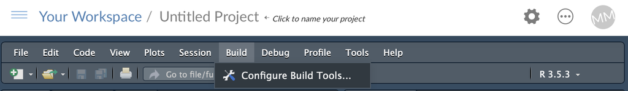

Choose the options so that they look like in the image below:

[figure not shown]

This is not strictly necessary, but it does not hurt if you want to kickstart your exploration of alternative ways to build a package. The following is a mixture of exercises and exploratory activities that you have to go through. The right approach is to first read some of the sources listed above, and then to go through each block in this document. Please do not advance unless you are confident you are mastering the content.

#### Exploratory activity

In order to create a package, you will use some tools that:

- assist you in creating a folder struture where all you code and documentation wil be, organised according to some specific rules
- build the package; to do so, R takes a folder (the one you just created) filled with some code and documentation and creates the R package. You can think to this process as a very special zip or compress operation, in which the compressing function has expectations on what has to be found in the folder.

The tools will mostly be implemented with console commands. The same operations can be completed clicking on options in the RStudio menu. You can use both, but I will lead you through the details of console commands as that is the easiest way to understand how things work.

Both the folder and the package need names. In this example below, we will use the name “cats” for both. In general, they can have different names.

The first thing you have to decide is where you want to create the folder containing your code and documentation. Have a look at where you are using the command `getwd()` and then move to the folder where you want to create your new package, i.e., a new folder named “cats”. For example, you could want to create a folder names “packages” and collect all you packages there. It’s your decision, spend a couple of minutes deciding how you want to organise your present and future code. From now on I will assume you have create a folder named “packages”

#### Create your package directory

After you have moved to the “packages” folder, it’s time to create your first package skeleton using the function `create()`:

```r
create("cats")
```

RStudio will complain and say that it is a bad idea to create a package inside a project. Just ignore it and choose to do it: you will be creating you first package skeleton. In most cases, RStudio will also create a new empty session and move you in the package structure. You can check running `getwd()` and eyeing the [empty] environment pane. As you are in a new session, you need to reload the “devtools” and “roxygen” packages using the commands above.

Right now the package is empty, as you didn’t write any code yet. Spend a couple of minutes in the “Files” pane exploring the structure of the package. You will notice two files, “DESCRIPTION” and “NAMESPACE”, and two folders, “man” (for documentation) and “R” (for your code). If the “man” folder is missing, don’t worry about that, we’ll create it later. But first, let’s build the first package running the `build()` command from the “devtools” package (which you previously loaded):

```r
build()
```

R will do a few checks on the structure of the package, and if everything is OK (which it is right now), it will create a package, in the form of a “cats_version.tar.gz” file. The file should be available in the “packages” folder, next to the “cats” folder. Congratulations! You just created your first [empty] package!

#### Add functions

We can now create our first function. Create an R script named “cat_function.R” in your R directory in the package folder and copy the code below.

```r
cat_function <- function(love=TRUE){
    if(love==TRUE){
        print("I love cats!")
    }
    else {
        print("I am not a cool person.")
    }
}
```

You can now rebuild the package, running again the command

```r
build()
```

#### Add documentation

The package roxygen2 makes everything amazing and simple. The way it works is that you add special comments to the beginning of each function, that will later be compiled (**processed**) into the correct format for package documentation. The details can be found in the roxygen2 documentation — I will just provide an example for our cat function.

The comments you need to add at the beginning of the cat function are, for example, as follows:

```r
#' A Cat Function
#'
#' This function allows you to express your love of cats.
#' @param love Do you love cats? Defaults to TRUE.
#' @keywords cats
#' @export
#' @examples
#' cat_function()

cat_function <- function(love=TRUE){
    if(love==TRUE){
        print("I love cats!")
    }
    else {
        print("I am not a cool person.")
    }
}
```

Some prefer creating a new file for each function, others (like myself) create new functions sequentially in one R file, possibly using several R files to cluster the functions according to some criteria. In any case, just make sure to add the documentation comments before each function.

#### **Process** your documentation

Now you need to create the documentation. You’ve already done the “hard” work when you wrote those special comments before the function `cat_function()`. The command `document()` reads those annotations and does mostly two things: (1) creates the .Rd files in the man directory, (2) adds or replaces the NAMESPACE file in the main directory of the package. *For now, don’t worry about the NAMESPACE file, it’s too advanced for this subject.* In order to run the `document()` command you have to be into the package folder. You should be there, but you can check running the usual command `getwd()`.

```r
# Go into the cats folder
getwd("./cats")
document()
```

If you have configured the Build tools correctly, you can run the same command more easily (i.e. without changing folder) from the RStudio interface by clicking on Build/Document. Feel free to do this. Also remember: **everyone forget to compile the documentation before building/installing packages**. Try to take a mental note that you need to do this, otherwise you will end up with old documentation in the package, even if you modified it. You can read up more about the files just created in the “man” directory, and inspect them if you wish, but in terms of steps you need to take, you really don’t have to do anything further.

#### Install

Now it is as simple as installing the package! You need to run this from the parent working directory that contains the cats folder.

```r
# Go back to the root folder
setwd("..")
install("cats")
```

Now you have a real, live, functioning R package. For example, try typing `?cat_function` or `cat_function()`. You should see the standard help page pop up and the function you wrote running.

It time to head to the DESCRIPTION file and modify it as you prefer. Note that you can decide the version umber of your package. It is good practice to start with a 0.# version, and pass to 1.# when the package is stable and can be safely circulated. Every minor version should advance like 1.0, 1.1, 1.2, …, 1.11, 1.12, etc. Every major version of the package advances the leading digit: 2.0, 3.0, etc.

If you want to have even more fun, you can create new functions with their documentation, and repeat the steps just taken.

## 2. Combine the skills learnt so far - Create an R package

In this exercise, you will solve a similar problem to Exercise 2 in week 9, but this time you will put the code in a package.

You should have in your toolkit from last week the following functions:

- `new_card(name, age, langs=NULL, cols=NULL)`: a function that creates an object of class “card”
- `print.card(card)`: a method to print an object of class “card”
- `new.cabinet()`: a function to create a “cabinet”, i.e. a list of class “cabinet” able to contain “cards”
- `add_card.cabinet(cabinet, card)`: a function to add a “card” to a “cabinet”.
- `list_cards.cabinet(cabinet)`: a function to list al cards contained in a “cabinet”
- `del_card.cabinet(cabinet, card_id)`: a function to delete a “card” from a “cabinet”
- `search.cabinet(cabinet, age_min, age_max)`: a function to search in a “cabinet” and return a summary of all cards with individuals within a specific age range [age_min, age_max] (boundaries included).

Write an R package named “cards” that contains all the functions listed above.

As in week 9, we have to teach R about the new methods in town. In the context of an R package, we need to “export” both the UseMethod statement and the functions (as we already did in the “cats” package), adding the Roxygen2 comment `#' @export` before any function, those containing the UseMethod statement and the functions we want users to be able to run. Below you can learn how to export the UseMethod statements and the functions, of which one example is given.

One more detail: please note we have changed “search” into “search_card” to avoid conflicts with the base R function `search()`.

```r
# Teach R about the new methods in towm

#' @export
add_card <- function(x, ...){
  UseMethod("add_card")
}

#' @export
list_cards <- function(x, ...){
  UseMethod("list_cards")
}

#' @export
del_card <- function(x, ...){
  UseMethod("del_card")
}

#' @export
search_card <- function(x, ...){
  UseMethod("search_card")
}

#' @export
new_card <- function(name, age, langs=NULL, cols=NULL){
  ## YOUR CODE HERE
}

## ALL OTHER FUNCTIONS HERE, PRECEDED BY THE EXPORT STATEMENTS
```

Create a package in the form of a tar.gz file (e.g. cards_0.1.tar.gz, the number refer to the package version and can differ), and download it locally.

- Demo: run the commands below to check that the package works as expected.

To test your package, create a new project in RStudio, upload the tar.gz file you downloaded from the “Files” pane, and (assuming the file is named “cards_0.1.tar.gz”) install it with the command:

```r
install.packages("../cards_0.1.tar.gz", repos=NULL)
```

Run the commands below to complete the demo.

```r
###################################
# Demo
###################################

## Load the package
library(cards)
# Create some cards
bob_card = new_card(name="Bob", age=23, langs=c("English", "Mandarin"), cols=c("red", "blue"))
mary_card = new_card(name="Mary", age=27, langs=c("English"), cols=c("red", "blue", "yellow"))
bruce_card = new_card(name="Bruce", age=18)
# Have a look at the cards (these really invoke print())
bob_card
mary_card
bruce_card
# Should obtain the same results
print(bob_card)
print(mary_card)
print(bruce_card)

# Create a new cabinet
cc=new_cabinet()

# Add, list, delete cards
cc <- add_card(cc, bob_card)
cc <- add_card(cc, mary_card)
cc <- add_card(cc, bruce_card)
str(cc)
list_cards(cc)
cc <- del_card(cc, "c3")
cc <- add_card(cc, bruce_card)
str(cc)
list_cards(cc)

# Search cards
search_card(cc, 21,25)
search_card(cc, 21,28)
search_card(cc, 21,27)

# A convenient way to collect examples is to write the testing code in the @example section of the documentation. Check the "cats" package and try to write the documentation so that the command below can be run. Ask your tutor and look at the solutions if you can't do it.
example("search_card.cabinet")
```